# Homework 3 Solution

## Problem 1 - Duality Practice

## Primal Linear Program

Consider the following primal linear program:

\begin{align*} \text{Maximize} \quad & z = 7x_1 - 3x_2 + 2x_3 + x_4 \\ \text{subject to} \quad & x_1 - x_2 = 5 \\ & 4x_2 + 6x_3 \leq 9 \\ & x_1 - x_3 - 2x_4 \leq 4 \\ & x_1 \geq 0, \quad x_2 \text{ free}, \quad x_3 \geq 0, \quad x_4 \leq 0 \end{align*}

## Dual Linear Program

### Primal to Dual Conversion

For each constraint in the primal, introduce a dual variable:

1. $ x_1 - x_2 = 5 \rightarrow y_1 $ (equality constraint)
2. $ 4x_2 + 6x_3 \leq 9 \rightarrow y_2 $ (inequality constraint)
3. $ x_1 - x_3 - 2x_4 \leq 4 \rightarrow y_3 $ (inequality constraint)

The primal objective function:

$ z = 7x_1 - 3x_2 + 2x_3 + x_4 $

Becomes the right-hand side of the dual constraints.

The primal constraints coefficients:

\begin{align*} \text{Constraint 1: } & (1, -1, 0, 0) \\ \text{Constraint 2: } & (0, 4, 6, 0) \\ \text{Constraint 3: } & (1, 0, -1, -2) \end{align*}

Form the dual objective function.

### Dual Problem

The dual linear program will be:

\begin{align*} \text{Minimize} \quad & w = 5y_1 + 9y_2 + 4y_3 \\ \text{subject to} \quad & y_1 + y_3 \geq 7 \\ & -y_1 + 4y_2 \geq -3 \\ & 6y_2 - y_3 \geq 2 \\ & -2y_3 \geq 1 \\ & y_1 \text{ free}, \quad y_2 \geq 0, \quad y_3 \geq 0 \end{align*}

```julia
using JuMP, GLPK

model = Model(GLPK.Optimizer)

@variable(model, y1)
@variable(model, y2 >= 0)
@variable(model, y3 >= 0)

@objective(model, Min, 5y1 + 9y2 + 4y3)

@constraint(model, y1 + y3 >= 7)
@constraint(model, -y1 + 4y2 >= -3)
@constraint(model, 6y2 - y3 >= 2)
@constraint(model, -2y3 >= 1)

optimize!(model)

println("Optimal objective value: ", objective_value(model))
println("y1 = ", value(y1))
println("y2 = ", value(y2))
println("y3 = ", value(y3))
```

[output not shown]

## Problem 2 - Max Flow Formulation

Delta Airlines has various types of planes with specific route capabilities. The goal is to determine how these planes can be assigned to routes to meet the required number of routes per day.

#### Network Nodes and Flows:

- **Source Node (S)**: Origin of flow representing the availability of planes.
- **Plane Type Nodes (A, B, C, D)**: Representing different types of planes available.
- **Route Nodes (R1, R2, R3, R4)**: Target nodes representing the routes that need to be flown.
- **Sink Node (T)**: Destination of flow representing the requirement of routes.

#### Mathematical Formulation:

**Variables:**

- $ f_{ij} $: Flow from node $ i $ to node $ j $

**Objective:**

- Maximize the total flow from the source to the sink.

$ \text{maximize} \quad \sum_{j \in T} f_{sj} $

This formulation ensures that all available planes are considered for assigning to routes while meeting the required number of routes each day, thus maximizing the airline's daily operational capacity.

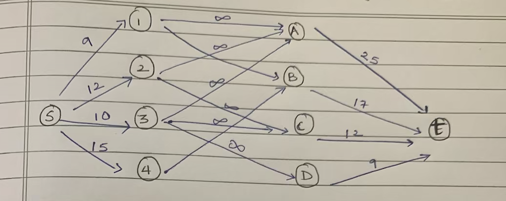

```julia
using JuMP, GLPK

model = Model(GLPK.Optimizer)

plane_types = [:A, :B, :C, :D]
routes = [:R1, :R2, :R3, :R4]
source = :source
sink = :sink

plane_availabilities = Dict(:A => 25, :B => 17, :C => 12, :D => 9)
route_requirements = Dict(:R1 => 9, :R2 => 12, :R3 => 10, :R4 => 15)

connections = [
    (source, :A), (source, :B), (source, :C), (source, :D),
    (:A, :R1), (:A, :R2), (:A, :R3), (:A, :R4),
    (:B, :R1), (:B, :R3), (:B, :R4),
    (:C, :R2), (:C, :R3),
    (:D, :R3),
    (:R1, sink), (:R2, sink), (:R3, sink), (:R4, sink)
]

@variable(model, flow[connections] >= 0)

for p in plane_types
    @constraint(model, sum(flow[(source, p)]) <= plane_availabilities[p])
end

for r in routes
    @constraint(model, sum(flow[(r, sink)]) == route_requirements[r])
end

for p in plane_types
    for r in routes
        if (p, r) in connections
            @constraint(model, flow[(source, p)] >= flow[(p, r)])
            @constraint(model, flow[(p, r)] >= flow[(r, sink)])
        end
    end
end

@objective(model, Max, sum(flow[(source, p)] for p in plane_types))

optimize!(model)

if termination_status(model) == MOI.OPTIMAL
    println("Optimal solution found:")
    for (i, j) in connections
        println("Flow from $i to $j: ", value(flow[(i, j)]))
    end
else
    println("No optimal solution found.")
end
```

```
No optimal solution found.
```

#### Thus there is no optimal solution for this problem

## Problem 3 - Craft Brewing Duality

#### Part (a)

```julia
using JuMP, GLPK

model = Model(GLPK.Optimizer)

@variable(model, x1 >= 0)
@variable(model, x2 >= 0)
@variable(model, x3 >= 0)
@variable(model, x4 >= 0)

@objective(model, Max, 60x1 + 120x2 + 200x3 + 300x4)

@constraint(model, c1, 2x1 + 3x2 + 3x3 + 5x4 <= 12000)
@constraint(model, c2, 5x1 + 5x2 + 10x3 + 15x4 <= 32000)
@constraint(model, c3, 0.25x1 + x2 + 2x3 + 3.5x4 <= 5000)

optimize!(model)

optimal_objective_value = objective_value(model)
x1_value = value(x1)
x2_value = value(x2)
x3_value = value(x3)
x4_value = value(x4)

println("Optimal objective value: ", optimal_objective_value)
println("x1 = ", x1_value)
println("x2 = ", x2_value)
println("x3 = ", x3_value)
println("x4 = ", x4_value)

dual_c1 = dual(model[:c1])
dual_c2 = dual(model[:c2])
dual_c3 = dual(model[:c3])

println("Dual value of c1: ", dual_c1)
println("Dual value of c2: ", dual_c2)
println("Dual value of c3: ", dual_c3)
```

```
Optimal objective value: 584888.8888888889
x1 = 1866.6666666666665
x2 = 977.7777777777777
x3 = 1777.7777777777778
x4 = 0.0
Dual value of c1: -13.333333333333329
Dual value of c2: -3.5555555555555562
Dual value of c3: -62.22222222222224
```

#### Part (b)

\begin{align*} \text{Maximum amount} = | \text{Dual value of c1} | = | -13.33 | = 13.33 \end{align*}

#### Part (c)

New profit contributions:

- Beer 2: $ 120 + 10 = 130 $
- Beer 3: $ 200 + 15 = 215 $

The new optimal profit is estimated by substituting the new profit contributions in the objective function:

$ z^*_{NEW} = 60 \cdot 1866.67 + 130 \cdot 977.78 + 215 \cdot 1777.78 + 300 \cdot 0 = 112000.2 + 127111.4 + 382222.7 = 621334.3 $

Since the increase in profit only makes the objective function higher, this estimate serves as a lower bound:

$ z^*_{NEW} \geq 621334.3 $

#### Part (d)

To estimate the new optimal profit, we need to consider the effect of changing the right-hand side of the constraints on the objective function. The changes are:

- Decrease labor availability by 1000 hours: New labor constraint is $ 12000 - 1000 = 11000 $
- Increase vat availability by 4000 hours: New vat constraint is $ 32000 + 4000 = 36000 $

Using the dual values, we can estimate the impact on the objective function:

\begin{align*} \text{Change in objective value} = (\text{Dual value of c1} \times -1000) + (\text{Dual value of c2} \times 4000) \text{Change in objective value} = (-13.33 \times -1000) + (-3.56 \times 4000) = 13330 - 14222.22 = -892.22 \end{align*}

The new optimal profit:

$ z^*_{NEW} = 584888.89 - 892.22 = 583996.67 $

Since this change negatively affects the profit, this estimate serves as an upper bound:

$ z^*_{NEW} \leq 583996.67 $

#### Part (e)

To determine the bound on $ T $, we need to ensure the profit per keg of the new beer covers the additional labor and vat hours required.

The contribution to the objective function should be greater than the shadow prices (dual values) for the labor and vat hours:

$ 400 \geq 10 \cdot | \text{Dual value of c1} | + 4 \cdot | \text{Dual value of c2} | $

$ 400 \geq 10 \cdot 13.33 + 4 \cdot 3.56 $

$ 400 \geq 133.3 + 14.22 $

$ 400 \geq 147.52 $

So the beer is potentially profitable if:

$ T \geq 0 \text{ (since the beer is already profitable with current values)} $

Considering inventory constraints:

$ 10x_4 + 4x_4T \leq 5000 $

$ x_4(10 + 4T) \leq 5000 $

$ T $ should be such that this constraint does not get violated. Solving for $ x_4 $ with current values can be complex without exact values but would be a guess-and-check method around these values.

Therefore, $ T \leq 500 $.

## Problem 4 - A graphical approach to duality

#### Linear Program Description

Consider the linear program:

$ \text{maximize} \quad x_1 - x_2 $ $ \text{subject to} \quad x_1 + 3x_2 \leq 6 $ $ 2x_1 + 4x_2 \leq 5 $ $ x_1, x_2 \geq 0 $

#### (a) Dual of the Linear Program

The dual of the given primal linear program can be formulated by following the standard LP duality rules:

$ \text{minimize} \quad 6y_1 + 5y_2 $ $ \text{subject to} \quad y_1 + 2y_2 \geq 1 $ $ 3y_1 + 4y_2 \geq -1 $ $ y_1, y_2 \geq 0 $

#### (b) Analysis of a Potential Solution

To verify if $ x_1 = \frac{1}{2} $ and $ x_2 = 1 $ with an objective value of $ -\frac{1}{2} $ is an optimal solution:

- Substitute $ x_1 $ and $ x_2 $ into the constraints:
  - For $ x_1 + 3x_2 \leq 6 $ : $ \frac{1}{2} + 3 \times 1 = 3.5 $ which satisfies the constraint.
  - For $ 2x_1 + 4x_2 \leq 5 $ : $ 2 \times \frac{1}{2} + 4 \times 1 = 5 $ which exactly satisfies the constraint.
- The objective function value is $ x_1 - x_2 = \frac{1}{2} - 1 = -\frac{1}{2} $.
- Since the solution satisfies all constraints and the calculation of the objective function is correct, this is an optimal solution if it lies on the boundary formed by the intersection of the constraints.

#### (c) Graphical Method

```julia
using Plots
plot()

# Define and plot the constraints
f1(x) = (6 - x) / 3
f2(x) = (5 - 2x) / 4

plot(f1, 0, 3, label="x1 + 3x2 ≤ 6")
plot!(f2, 0, 3, label="2x1 + 4x2 ≤ 5")

# Add feasible region
x_fill = [0, 0.5, 2.5, 3]
y_fill = [0, 1, 0, 0]
plot!(x_fill, y_fill, fill=(0, 0.5, :blue), label="Feasible Region")

# Highlight the optimal point
scatter!([0.5], [1], label="Optimal Point (0.5, 1)", color="red")

xlabel!("x1")
ylabel!("x2")
title!("Graphical Representation of the LP")
```

[figure not shown]